# Introdução ao R

01/08/2022

## Sobre o R

O R é um ambiente de programação estatístico, desenvolvido por dois acadêmicos: Ross Ihaka e Robert Gentleman na Univesidade de Auckland (Nova Zelândia) em 1993.

Além de um ambiente de programação, o R também é uma linguagem de programação de alto nível:

- É um ambiente porque foi planejado com um conjunto de funcionalidades relacionadas e adaptáveis;
- É uma linguagem de programação porque permite criar e modificar funções, além de alterar objetos nela;
- É de alto nível porque não requer do usuário empregar código binário;

## O que o R faz?

São várias as utilidades do R:

- Criar e usar funções;
- Abrir, modificar, criar e salvar qualquer tipo de arquivo;
- Interagir com outros recursos num computador ou servidor;
- Manipulação de dados (gerar, fatiar, organizar, rearranjar, converter e exportar);
- Modelagem (aplicar ou desenvolver qualquer modelo estatístico);
- Visualização (visualizar qualquer tipo de dados de forma simples);
- Automatização (produzir rotinas, autômatos ou funções).

## O que o R faz?

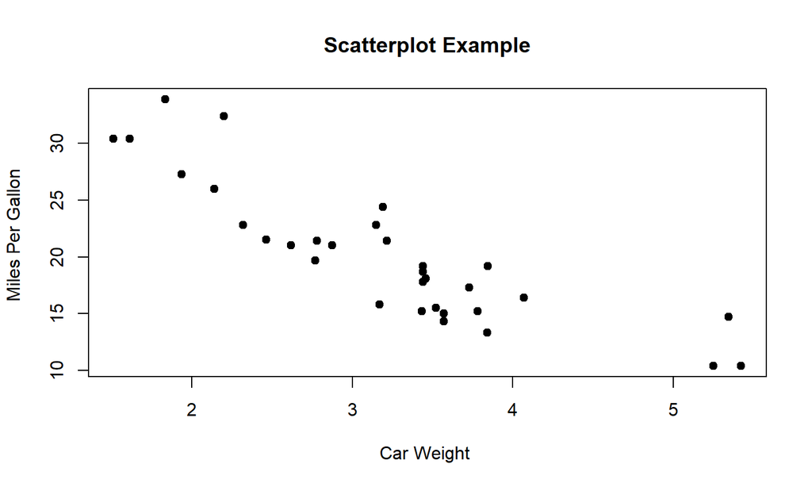

## O que o R faz?

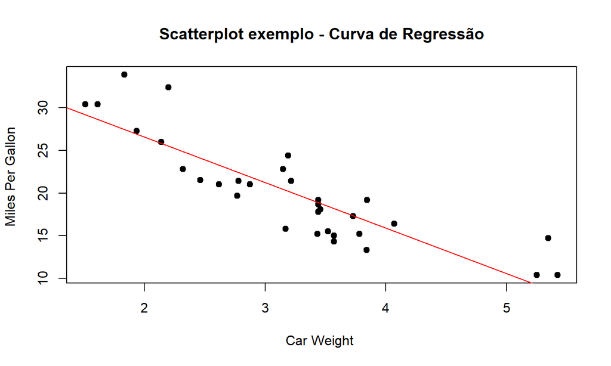

## O que o R faz?

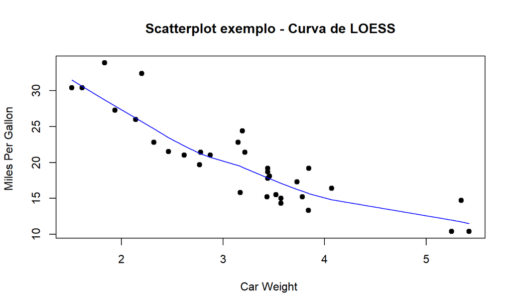

## O que o R faz?

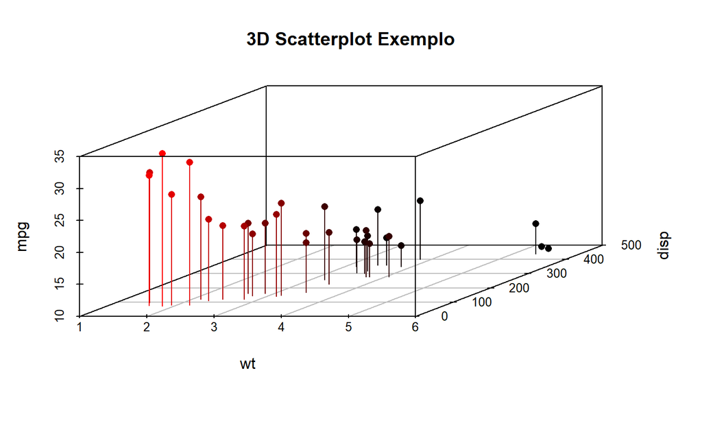

## O que o R faz?

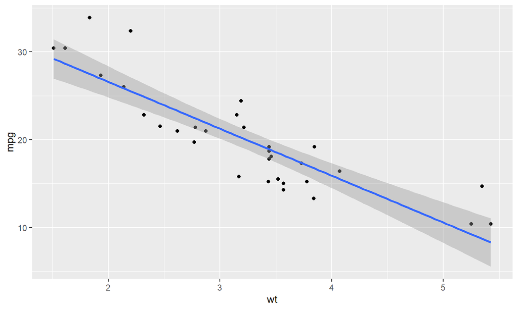

## O que o R faz?

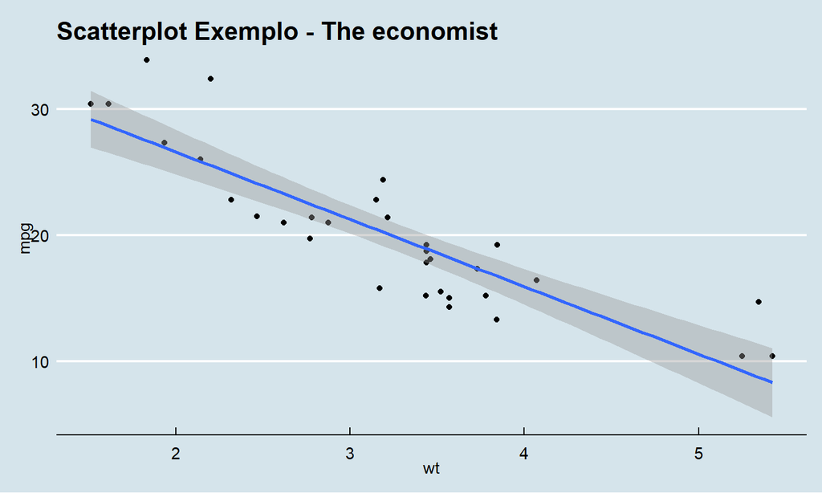

## O que o R faz?

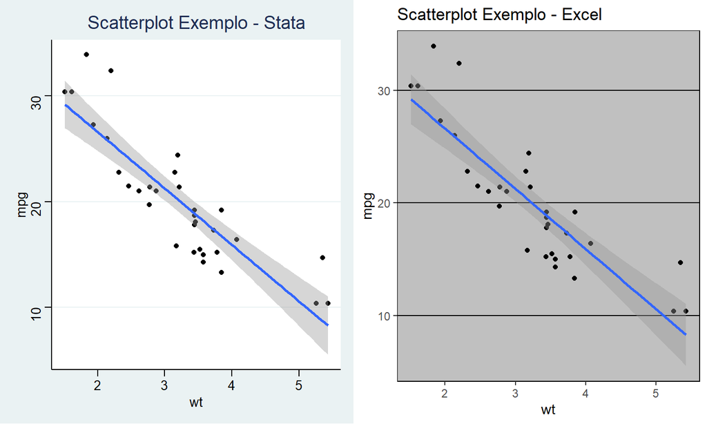

## O que o R faz?

```
##
## Call:
## lm(formula = y ~ x)
##
## Residuals:
##      Min       1Q   Median       3Q      Max
## -2.81350 -0.65021  0.08214  0.42371  3.09049
##
## Coefficients:
##             Estimate Std. Error t value Pr(>|t|)
## (Intercept)  0.07810    0.14678   0.532    0.597
## x            0.02115    0.14913   0.142    0.888
##
## Residual standard error: 1.034 on 48 degrees of freedom
## Multiple R-squared:  0.000419,   Adjusted R-squared:  -0.02041
## F-statistic: 0.02012 on 1 and 48 DF,  p-value: 0.8878
```

## O uso do R

O R é uma das principais ferramentas do mercado de trabalho e amplamente utilizado na academia.

Entre suas principais vantagens:

- É gratuito;
- Envolve uma comunidade extensa de desenvolvedores;
- Replicabilidade;
- Integração entre tarefas;
- Agilidade.

## Nosso curso

O curso tem como objetivo introduzir aos alunos o R. E vamos passar pelas seguintes funcionalidades:

- Sintaxe básica do R (Gramática);
- Manipulação de dados I;
- Manipulação de dados II;
- Análises estatísticas descritivas;
- Introdução para a elaboração de gráficos.